# MXB344 Lecture 8

11 September 2016

## Welcome

MXB344 Lecture 8

## House Keeping

- Your assignment marks have been released. Please feel free to ask for clarification of any of my comments.
- I will be calling for your your delivery plans in today's practical.

## Selecting Variables

- Last week we introduced the ideas of correlation cutoffs and single variable regression measures.
- This week we will introduce VIF and see some examples of these 3 methods.
- Reminder: The problem context is we have a large number of covariates we which to reduce to a more manageable set.
  - **Multicollinearity** is a common problem associated with large numbers of covariates. Addressing this has the **side effect** of reducing the covariate set.
  - **Variable importance** measures can help us reduce the covariate set and help us understand the model's performance. Typically we need to fit some kind of model to determine variable importance.

## Variance Inflation Factor (VIF)

- A common diagnostic statistic for multicollinearity.
- For normal linear models the VIF is defined:

\[VIF_{i} = \frac{1}{1-R_{i}^{2}}\]

- Where \(R_{i}^{2}\) is the \(R^{2}\) obtained from fitting a linear model to \(X_{i}\), using all other covariates as the explanatory variables. The response, \(Y\), is ignored.
- VIF > 5 suggests investigation/intervention needed.
- For GLM's \(R^{2}\) is not defined.

## Generalised Variance Inflation Factor (GVIF)

- \(GVIF_{i}\) is instead formulated from the ratio of determinants of correlation matrices of our full data matrix, \(X\) and the data matrix without rows and columns for \(i\), \(X_{/i}\).
- \(X_{/i}\) may differ by a number of columns if \(X_{i}\) is categorical.
- The determinant of the correlation matrix is a common indicator of multicollinearty. 1 = Uncorrelated columns, 0 = correlated.
- For our purposes we don't really care.
- We have a VIF we can use for GLMS.
  - The R function to use is `vif()` from the `car` package.

## Example: Backpain

- We consider a kaggle dataset created to model [abnormal backpain](https://www.kaggle.com/sammy123/lower-back-pain-symptoms-dataset).
- It is characterised by 12 numeric measurements that sure exhibit some degree of correlation?

```
## Observations: 310
## Variables: 13
## $ pelvic_incidence         <dbl> 63.02782, 39.05695, 68.83202, 69.2970...
## $ pelvic_tilt              <dbl> 22.552586, 10.060991, 22.218482, 24.6...
## $ lumbar_lordosis_angle    <dbl> 39.60912, 25.01538, 50.09219, 44.3112...
## $ sacral_slope             <dbl> 40.47523, 28.99596, 46.61354, 44.6441...
## $ pelvic_radius            <dbl> 98.67292, 114.40543, 105.98514, 101.8...
## $ degree_spondylolisthesis <dbl> -0.2544000, 4.5642586, -3.5303173, 11...
## $ pelvic_slope             <dbl> 0.74450346, 0.41518568, 0.47488916, 0...
## $ direct_tilt              <dbl> 12.5661, 12.8874, 26.8343, 23.5603, 3...
## $ thoracic_slope           <dbl> 14.5386, 17.5323, 17.4861, 12.7074, 1...
## $ cervical_tilt            <dbl> 15.30468, 16.78486, 16.65897, 11.4244...
## $ sacrum_angle             <dbl> -28.658501, -25.530607, -29.031888, -...
## $ scoliosis_slope          <dbl> 43.5123, 16.1102, 19.2221, 18.8329, 2...
## $ abnormal_pain            <dbl> 1, 1, 1, 1, 1, 1, 1, 1, 1, 1, 1, 1, 1...
```

## Exploring the Corellation Matrix

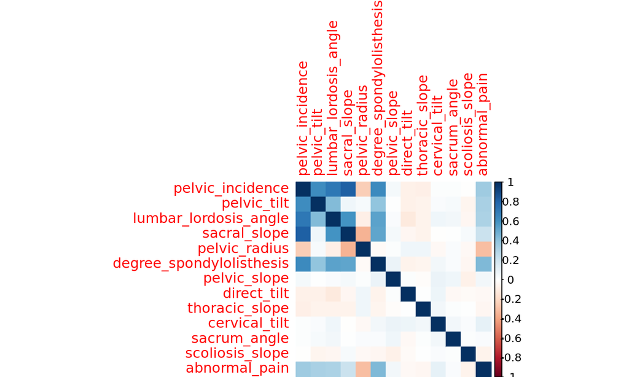

## Removing Correlated Covariates with Caret

```r
correlated_covs <-
  spine_data %>%
  select(-abnormal_pain) %>%
  cor() %>%
  findCorrelation(cutoff = 0.8)

spine_data  <-
  spine_data[-correlated_covs]
```

## Applying GVIF

- GVIF is calculated on fitted model objects.

```r
glm_fit_all <- glm(data = spine_data,
                   formula = abnormal_pain ~ .,
                   family = binomial(link="logit"))
car::vif(glm_fit_all)
```

```
##              pelvic_tilt    lumbar_lordosis_angle             sacral_slope
##                 1.267463                 3.072955                 3.346255
##            pelvic_radius degree_spondylolisthesis             pelvic_slope
##                 1.412740                 1.669607                 1.080305
##              direct_tilt           thoracic_slope            cervical_tilt
##                 1.121417                 1.072926                 1.085646
##             sacrum_angle          scoliosis_slope
##                 1.030445                 1.048900
```

- A pitfall of using GVIF is that it can give nonsense answers when there is perfect linear dependency in the covariate data.

## Strategy: Select Best Individual General Linear Regressors

- I wrote some code using the `purrr` package. You can achieve the same thing with loops.

```r
spine_model_fits <-
  spine_data %>%
    gather(key="measure",
           value="value",
           pelvic_tilt:scoliosis_slope) %>%
    nest(abnormal_pain, value) %>% #could replace invoke_rows with a loop.
    invoke_rows(.f =
                  function(measure, data){
                      glm(data=data,
                        formula = abnormal_pain ~ value,
                        family=binomial(link="logit")) %>%
                      glance()
                   },
                 .d = .,
                 .collate = "rows") %>%
    arrange(AIC)
```

## Plotting Single Regressor Summary Stats

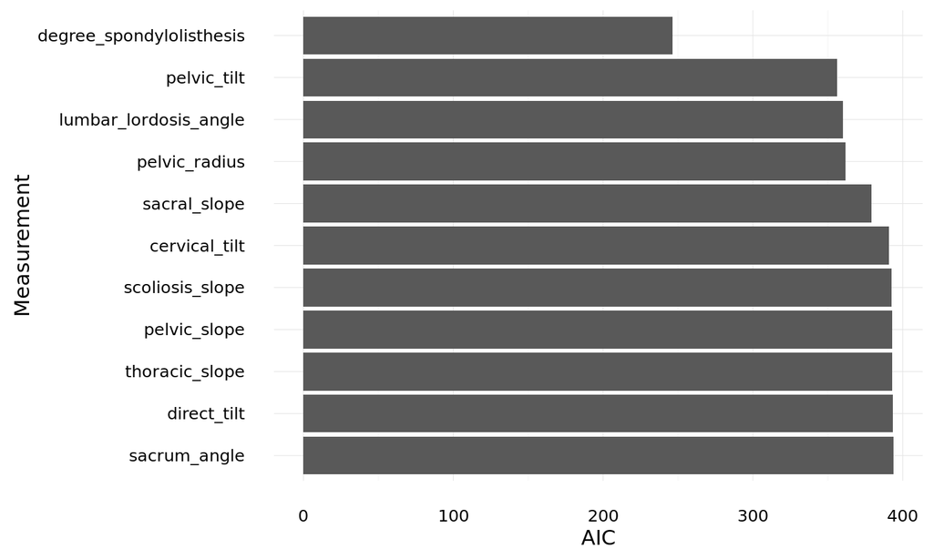

## Comparing Predictive Models

## Special considerations for predictive models

- Explanatory statistical models seek to optimise the fit to **observed data**. They seek to explain phenomena and events.
- Predictive models seek to optimise fit to **unobserved data**. The seek to predict phenomena and events.

How can we optimise a model for data that is unobserved?

## Hold-out data

- We hold-out some data from the fitting process and **pretend** it is unobserved.
- For this pretense to be useful we have to select the hold-out data appropriately.
- Example: Time series model to predict future needs hold-out data in future. You can't predict the past.
- When comparing models we give the most weight to accuracy measures calculated on hold-out data.

## Cross validation

- The hold out data concept is formalised in practice called *Cross Validation* or *CV*.
- CV schemes: 2-fold, n-fold, LOOCV
- In R: `caret` and `boot` provide facilities for cross validation

## Example: Spine Data Fit

- Based of our importance plot, using 5-fold CV:

```r
glm_fit <- train(as.factor(abnormal_pain) ~ degree_spondylolisthesis +
                 pelvic_tilt + lumbar_lordosis_angle +
                   pelvic_radius + sacral_slope,
                 data=spine_data,
                 method="glm",
                 family=binomial(link="logit"),
                 trControl=trainControl(method="cv", number=5)
               )
```

- Need to use `as.factor()` for **classification** model.

## Plot Accuracy

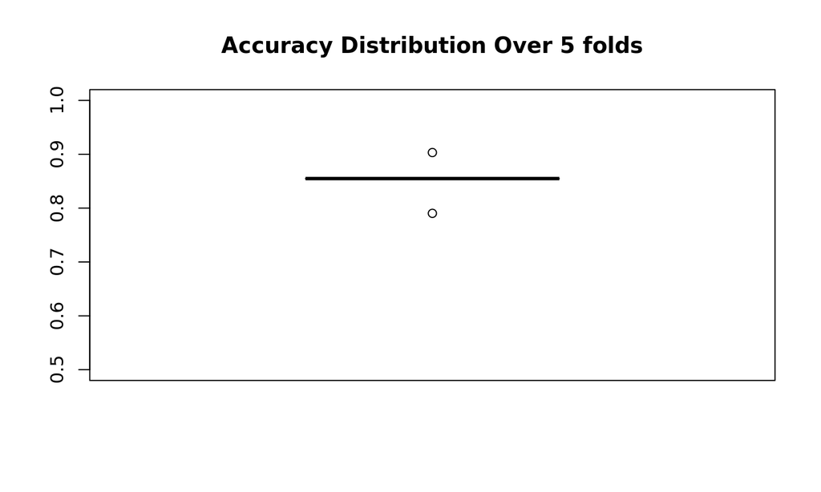

```r
glm_fit$resample$Accuracy %>%
  boxplot(main="Accuracy Distribution Over 5 folds", ylim=c(0.5,1))
```

* Is this model reliable?

## Accuracy Measures

- **Accuracy** For logistic regression is just the number 0's and 1's our model assigned correctly out of total observations in set.
- **Kappa** is defined as: \[\frac{O_{A} - E_{A}}{1-E_{A}}\]

Where \(O_{A}\) = Observed Accuracy and \(E_{A}\) = Expected Accuracy

## Psuedo R^2

- Although R^2 is not defined for GLMs, there have been attempts to create a summary statistic with similar interpretation.
- You can find a list of them [here](http://www.ats.ucla.edu/stat/mult_pkg/faq/general/Psuedo_RSquareds.htm)
- It is common for many Machine Learning flavoured packages to give an R^2 for GLMs.
- The most choice for GLMs is McFadden's Pseudo R^2 value:

\[1 - \frac{l(\hat{\theta}; y)}{l(\hat{\theta}_{null}; y)} \]

**Note:** The log-likelihood of a saturated model is 0.

## Example Pseudo R^2

```r
glm_reduce <-
  glm(data = spine_data,
      formula = abnormal_pain ~ degree_spondylolisthesis +
                 pelvic_tilt + lumbar_lordosis_angle +
                   pelvic_radius + sacral_slope, family=binomial())

pscl::pR2(glm_reduce)
```

```
##          llh      llhNull           G2     McFadden         r2ML
##  -89.1304444 -194.9278122  211.5947356    0.5427515    0.4946801
##         r2CU
##    0.6912184
```

## ROC Curve

- The *Receiver operating characteristic (ROC)* curve is widely used way to quantify and compare binary predictive models.
- The name comes from WWII era radar operation manuals.
  - Concerned with True Postie (TP) vs False Postie (FP) detection of enemy aircraft.
- To understand the ROC curve we need to understand TPs, FPs and relationship with a cutoff

## Where to set the Cut-Off?

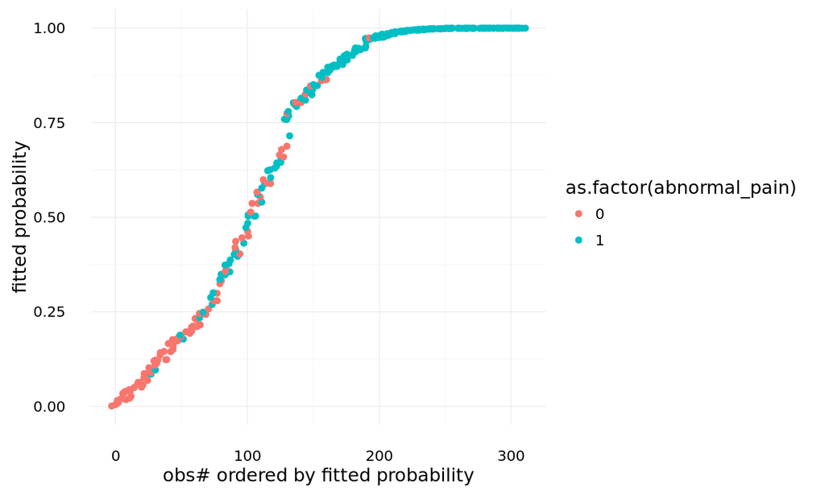

## A ROC Curve

- We're interested in how much 'ROC-space' is under the curve - Area Under Curve (AUC)

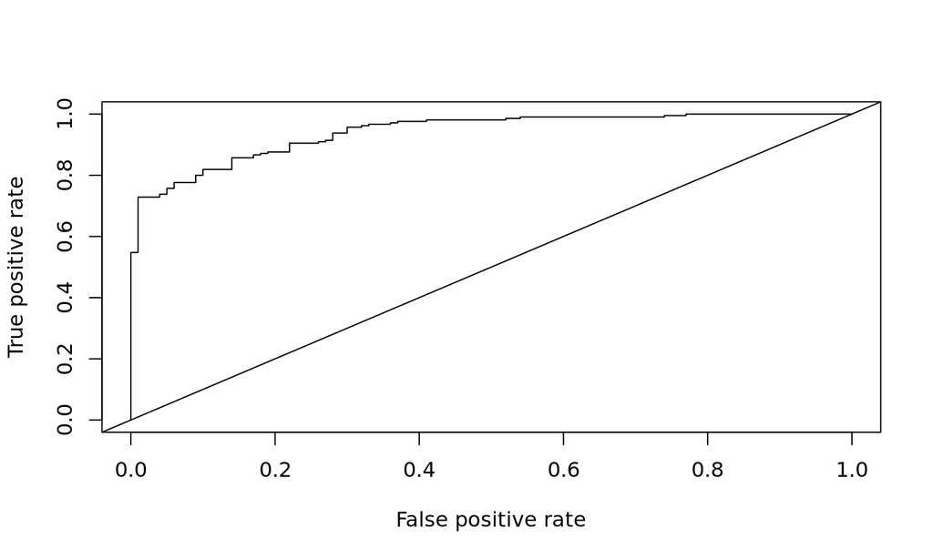

## Gini Coefficient

- AUC summarises a binary model's performance characteristics
- The Gini coefficient is rescaling of the AUC: \[ 2(AUC - 0.5) \]